# Task 2 - Exploratory Data Analysis

dillonchewwx

01/07/2021

# Task 2 - Exploratory Data Analysis

The first step in building a predictive model for text is understanding the distribution and relationship between the words, tokens, and phrases in the text. The goal of this task is to understand the basic relationships you observe in the data and prepare to build your first linguistic models.

Tasks to accomplish:

1. Exploratory analysis - perform a thorough exploratory analysis of the data, understanding the distribution of words and relationship between the words in the corpora.
2. Understand frequencies of words and word pairs - build figures and tables to understand variation in the frequencies of words and word pairs in the data.

# Load libraries

```r
library(tidyverse)
library(tm)
library(wordcloud)
```

# Load Corpus and convert into Document Term Matrix

```r
combined_Corpus<-readRDS("../Data/combined_Corpus.rds")
dtm<-DocumentTermMatrix(combined_Corpus)
inspect(dtm)
```

```
## <<DocumentTermMatrix (documents: 4269678, terms: 938023)>>
## Non-/sparse entries: 51421241/4005004745353
## Sparsity           : 100%
## Maximal term length: 354
## Weighting          : term frequency (tf)
## Sample             :
##          Terms
## Docs      can get good just like new one said time will
##   1022916   0   0    0    0    0   0   0    0    0    0
##   1415598   0   0    0    1    0   0   0    0    0    0
##   144333    5   2    3    0    1  10   6    0    1   22
##   296687    1   1    1    3    0   1   3    4    3    1
##   476221   10   1    0    3    5   0  14    0   10   21
##   483415    7   1    0    1    1   5   6   58    7   19
##   506059    0   1    0    0    0   0   5    3    2    0
##   517366   31   3    9    1    1  26  15    4    5   37
##   603795    8   1    1    3    0   9   3    0    2    6
##   694864    2   1    3    3    0   9   8    0    3    9
```

# Distribution of word frequency

```r
library(tidytext)

tidyDF<-tidy(dtm) %>%
    count(term, sort=TRUE)
glimpse(tidyDF)
```

```
## Rows: 938,023
## Columns: 2
## $ term <chr> "just", "said", "will", "one", "like", "can", "get", "time", "new~
## $ n    <int> 280538, 277406, 261394, 254929, 241917, 218005, 207805, 193851, 1~
```

The top five most common words across the 3 data sets are just, said, will, one, and like. Now let’s calculate the frequency for each word.

```r
frequency<-tidyDF %>%
    mutate(frequency = n/sum(n))
glimpse(frequency)
```

```
## Rows: 938,023
## Columns: 3
## $ term      <chr> "just", "said", "will", "one", "like", "can", "get", "time",~
## $ n         <int> 280538, 277406, 261394, 254929, 241917, 218005, 207805, 1938~
## $ frequency <dbl> 0.005455683, 0.005394775, 0.005083386, 0.004957659, 0.004704~
```

Likewise, we can make some plots to visualize the data.

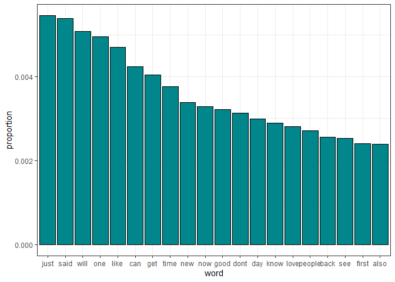

```r
ggplot(frequency %>% slice_head(n=20), aes(x=reorder(term, -frequency), y=frequency)) +
    geom_bar(stat="identity", fill="turquoise4", color="black") +
    theme_bw() +
    labs(x="word", y="proportion")
```

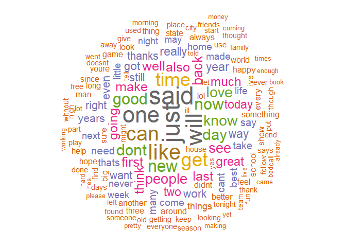

```r
set.seed(123)
wordcloud(words=frequency$term, freq=frequency$n, max.words=150,
          scale=c(3,0.5), random.order=FALSE,
          colors=brewer.pal(8, "Dark2"), rot.per=0.25)
```

# Unique words to cover 50% and 90% of all word instances

```r
coverage_50<-frequency %>%
  mutate(coverage=cumsum(frequency)) %>%
  filter(coverage<=0.5)
nrow(coverage_50)
```

```
## [1] 1017
```

```r
coverage_90<-frequency %>%
  mutate(coverage=cumsum(frequency)) %>%
  filter(coverage<=0.9)
nrow(coverage_90)
```

```
## [1] 17725
```

Here, we we see that 50% of all words are covered by just 1017 words, while 90% of all words are covered by 17725 words.

# Frequencies of 2-grams and 3-grams

So far, we have been considering words as individual units. However, many interesting text analyses are based on the relationships between words, whether examining which words tend to follow others immediately, or that tend to co-occur within the same documents. Here, we will use the `unnest_tokens` function from the `tidytext` package to tokenize into consecutive sequences of words. As we cannot use the `tm` package to carry out the same function, we cannot use the previously created Corpus and thus have to reload and clean up all the data before carrying out the analysis.

```r
blogs_file<-"../Data/en_US.blogs.txt"
news_file<-"../Data/en_US.news.txt"
twitter_file<-"../Data/en_US.twitter.txt"

blogs<-read_lines(blogs_file, skip_empty_rows=TRUE)
news<-read_lines(news_file, skip_empty_rows=TRUE)
twitter<-read_lines(twitter_file, skip_empty_rows=TRUE)

profanities<-read_tsv("https://www.cs.cmu.edu/~biglou/resources/bad-words.txt", col_names=FALSE) %>%
  rename(word=X1)
combined<-c(blogs, news, twitter) %>%
    gsub("http[^[:space:]]*", "", .) %>%
    str_to_lower() %>%
    gsub("[0-9]", "", .) %>%
    removePunctuation(ucp=TRUE) %>%
    stripWhitespace() %>%
    removeWords(profanities$word) %>%
    as.tibble()

head(combined, 10)
```

```
## # A tibble: 10 x 1
##    value
##    <chr>
##  1 "in the years thereafter most of the oil fields and platforms were named aft~
##  2 "we love you mr brown"
##  3 "chad has been awesome with the kids and holding down the fort while i work ~
##  4 "so anyways i am going to share some home decor inspiration that i have been~
##  5 "with graduation season right around the corner nancy has whipped up a fun s~
##  6 "if you have an alternative argument lets hear it "
##  7 "if i were a bear"
##  8 "other friends have similar stories of how they were treated brusquely by la~
##  9 "although our beloved cantab cant claim the international recognition afford~
## 10 "peter schiff hard to tell it will look pretty bad for most americans when p~
```

The cleaned up data is now stored in the `combined` variable and can be used for further processing. We shall now examine the 2-grams.

```r
bigrams<-combined %>%
  unnest_tokens(bigram, value, token="ngrams", n=2)

bigrams_frequency<-bigrams %>%
  count(bigram, sort=TRUE) %>%
  mutate(frequency = n/sum(n))

bigrams_coverage_50<-bigrams_frequency %>%
  mutate(coverage=cumsum(frequency)) %>%
  filter(coverage<=0.5)
nrow(bigrams_coverage_50)
```

```
## [1] 37258
```

```r
bigrams_coverage_90<-bigrams_frequency %>%
  mutate(coverage=cumsum(frequency)) %>%
  filter(coverage<=0.9)
nrow(bigrams_coverage_90)
```

```
## [1] 4570717
```

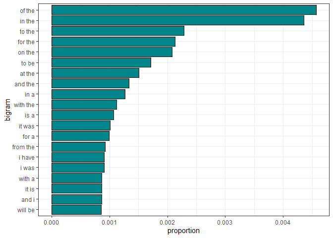

```r
ggplot(bigrams_frequency %>% slice_head(n=20), aes(x=reorder(bigram, frequency), y=frequency)) +
    geom_bar(stat="identity", fill="turquoise4", color="black") +
    theme_bw() +
    labs(x="bigram", y="proportion") +
    coord_flip()
```

For the 2-grams, we can see that 50% of all words are covered by just 37258 pairs, while 90% of all words are covered by 4570717 words. As for the distribution, we can see that the top few 2-grams largely consist of stop words such as “the”. We shall now take a look a the 3-grams.

```r
trigrams<-combined %>%
  unnest_tokens(trigram, value, token="ngrams", n=3)

trigrams_frequency<-trigrams %>%
  count(trigram, sort=TRUE) %>%
  mutate(frequency = n/sum(n))

trigrams_coverage_50<-trigrams_frequency %>%
  mutate(coverage=cumsum(frequency)) %>%
  filter(coverage<=0.5)
nrow(trigrams_coverage_50)
```

```
## [1] 3383049
```

```r
trigrams_coverage_90<-trigrams_frequency %>%
  mutate(coverage=cumsum(frequency)) %>%
  filter(coverage<=0.9)
nrow(trigrams_coverage_90)
```

```
## [1] 35109709
```

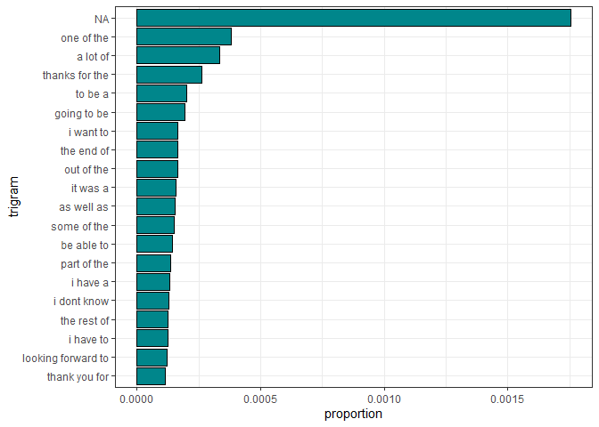

```r
ggplot(trigrams_frequency %>% slice_head(n=20), aes(x=reorder(trigram, frequency), y=frequency)) +
    geom_bar(stat="identity", fill="turquoise4", color="black") +
    theme_bw() +
    labs(x="trigram", y="proportion") +
    coord_flip()
```

Lastly for the 3-grams, we see that they are much more diverse with over 3 million making up 50% coverage, and 35 million for 90% coverage.